# Factors Affecting Voting Behavoir

Data Mining in R | Class Exercise 1

Ursulina Kölbener, Marco Graf und Sascha Eng

2023-03-11

## Introduction

How does age affect voting participation? The purpose of our project is to address this research question by investigating voting patterns by age group. We hypothesize that older adults are more likely to vote than young adults. To test our hypothesis, we use visualizations and apply a binary logit regression model on data from the European Social Survey (ESS) for individuals surveyed in Switzerland.

## Methods

### Data and Methods

The relationship between age and voting is analysed using visualizations, descriptive statistics and applying a binary logit regression model on survey data from the ESS Round 10 for the year 2020. The ESS data set contains the variables of interest and a reasonable number of observations which makes it suitable for the analysis. The final sample consists of 1,089 Swiss nationals surveyed in Switzerland, aged between 18 and 90 years with 5 to 21 years of education, and data on respondents’ voting participation in the last national election, interest in politics and region of residence.

### Variables

The variables of interest for the analysis are defined as follows:

- **Dependent variable**: `vote` is a binary variable which indicates whether or not the respondent voted in the last national election.
- **Independent variable:** `age_group` is a categorical variable which indicates whether an individual belongs to the age group young adults (18-35), middle-aged adults (36-55), or older adults (55+).
- **Control variables:** a set of control variables is used in the regression models to account for confounding effects: `polintr` (categorical variable indicating individual level of interest in politics), `gndr` (binary variable indicating whether respondent is male or female), `eduyrs` (continuous variable measuring the years of education), and `region` (categorical variable indicating the region of residence).

### Summary Statistics and Visualisations

#### Summary Statistics

```r
# some summary statistics
summary(ess_1)
```

```
##       idno        vote                      polintr        gndr
##  Min.   :10004   No :277   Not at all interested: 75   Male  :563
##  1st Qu.:14458   Yes:812   Hardly interested    :306   Female:526
##  Median :18921             Quite interested     :466
##  Mean   :18932             Very interested      :242
##  3rd Qu.:23290
##  Max.   :27921
##
##       agea        domicil             region               educ
##  Min.   :18.00   Urban:433   Lake Geneva :183   ES-ISCED I   :  5
##  1st Qu.:38.00   Rural:656   Middleland  :246   ES-ISCED II  :125
##  Median :54.00               North-West  :166   ES-ISCED IIIb:364
##  Mean   :52.69               Zurich      :175   ES-ISCED IIIa: 85
##  3rd Qu.:66.00               Eastern Part:166   ES-ISCED IV  :231
##  Max.   :90.00               Central Part:113   ES-ISCED V1  : 90
##                              Ticino      : 40   ES-ISCED V2  :189
##      eduyrs         cntry              ctzcntr   age_group
##  Min.   : 5.00   Length:1089        Min.   :1   young :239
##  1st Qu.: 9.00   Class :character   1st Qu.:1   middle:328
##  Median :10.00   Mode  :character   Median :1   older :522
##  Mean   :11.52                      Mean   :1
##  3rd Qu.:14.00                      3rd Qu.:1
##  Max.   :21.00                      Max.   :1
##
```

### Visualisation

To give an overall impression about voting participation by age, we created a scatterplot and added a bit of “noise”.

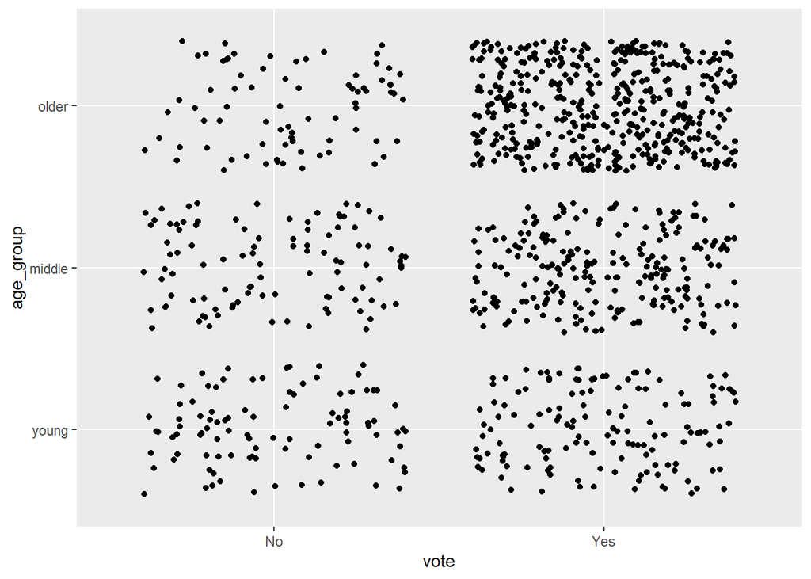

### Regression Analysis

#### Binary Logit Regression Model

The purpose of our project is to investigate the effect of age on voting participation. Because of the binary nature of the dependent variable vote, we apply a binary logit regression model to estimate the probability of voting given the main independent variable *age_group* and the control variables *polintr*, *gndr*, *eduyrs*, and *region*.

$P(y = yes|x) = \Lambda(x'\beta) = \frac{exp(x'\beta)}{1+(x'\beta)}$

where:

- $y$: dependent variable vote (categories: yes, no)
- $x'$: independent variables $(x_1, x_2, x_3, x_4, x_5)$
- $x_1$: main independent variable age_group (categories: young, middle-age, older)
- $x_2$: polintr (categories: not at all, hardly, quite, very interested)
- $x_3$: gndr (categories: male, female)
- $x_4$: eduyrs (continuous)
- $x_5$: region (categories: Lake Geneva, Middleland, North-West, Zurich, Eastern Part, Central Part, Ticino)
- $\beta$: coefficient
- $(x'\beta)$: regression function
- $\Lambda(x'\beta)$: cumulative distribution function applied to the regression function $(x'\beta)$

#### Regression Analysis

```r
## Regression Analysis

# Step 1: Load packages
library(stargazer)
library(mfx)

# Step 2: Set contrasts to handle ordered factors in the regression
options(contrasts = c("contr.treatment", "contr.treatment"))

# Step 3: Run a binary logit regression
logitmodel <- glm(vote ~ age_group + polintr + gndr + eduyrs + region, family = binomial(link = "logit"), data = ess_1)
```

#### Probability Changes

It should be noted that the coefficients of the estimated binary logit regression model do not have direct interpretation except for the direction and significance of the effects. In order to interpret the coefficients, they need to be translated into something related to probabilities. Therefore, based on the estimated binary logit regression model, we calculate the probability changes for all variables in the model.

```r
# Calculate the marginal effects for the binary logit regression
mfx <- logitmfx(logitmodel, atmean = TRUE, data = ess_1)
```

## Results

### Regression Results

#### Binary Logit Regression

Focusing on the age group variable, the output of the logit regression model reports the coefficients for each but one category. Here, young adults was chosen by R as the base category. Thus, the results show that middle-aged and older adults are more likely to vote than young adults which is statistically significant at the 5% and 1% level, respectively.

```r
# Results of the binary logit regression
stargazer(logitmodel, type = "text")
```

```
##
## ====================================================
##                              Dependent variable:
##                          ---------------------------
##                                     vote
## ----------------------------------------------------
## age_groupmiddle                    0.387**
##                                    (0.196)
##
## age_groupolder                    1.335***
##                                    (0.204)
##
## polintrHardly interested          1.335***
##                                    (0.295)
##
## polintrQuite interested           2.451***
##                                    (0.300)
##
## polintrVery interested            3.364***
##                                    (0.389)
##
## gndrFemale                          0.113
##                                    (0.160)
##
## eduyrs                            0.098***
##                                    (0.028)
##
## regionMiddleland                   -0.005
##                                    (0.251)
##
## regionNorth-West                   -0.151
##                                    (0.277)
##
## regionZurich                       -0.071
##                                    (0.278)
##
## regionEastern Part                  0.312
##                                    (0.284)
##
## regionCentral Part                  0.181
##                                    (0.316)
##
## regionTicino                        0.702
##                                    (0.484)
##
## Constant                          -2.775***
##                                    (0.493)
##
## ----------------------------------------------------
## Observations                        1,089
## Log Likelihood                    -496.822
## Akaike Inf. Crit.                 1,021.644
## ====================================================
## Note:                    *p<0.1; **p<0.05; ***p<0.01
```

#### Probability Changes

Pointing to the age group variable, the results of the probability change calculation show that if we compare middle-aged adults (36-55) with the base category young adults (18-35), then middle-aged adults, on average, are 5.89 %-points more likely to vote than young adults, controlling for polintr, gndr, eduyrs, and region. Further, if we compare older adults (56+) with the base category young adults, then older adults, on average, are 21 %-points more likely to vote than young adults, controlling for polintr, gndr, eduyrs, and region. Again, both results are statistically significant.

```r
# Results of the marginal effects for the binary logit regression
#mfx <- logitmfx(logitmodel, atmean = TRUE, data = ess_1)
mfx
```

```
## Call:
## logitmfx(formula = logitmodel, data = ess_1, atmean = TRUE)
##
## Marginal Effects:
##                                dF/dx   Std. Err.       z     P>|z|
## age_groupmiddle           0.05885684  0.02859303  2.0584 0.0395486 *
## age_groupolder            0.20982252  0.03110896  6.7448 1.533e-11 ***
## polintrHardly interested  0.17857951  0.03467927  5.1495 2.612e-07 ***
## polintrQuite interested   0.35718144  0.04258871  8.3868 < 2.2e-16 ***
## polintrVery interested    0.32619113  0.02617257 12.4631 < 2.2e-16 ***
## gndrFemale                0.01803184  0.02538304  0.7104 0.4774627
## eduyrs                    0.01560904  0.00436530  3.5757 0.0003493 ***
## regionMiddleland         -0.00076628  0.04010264 -0.0191 0.9847550
## regionNorth-West         -0.02486706  0.04691159 -0.5301 0.5960541
## regionZurich             -0.01143640  0.04564007 -0.2506 0.8021403
## regionEastern Part        0.04650172  0.03938254  1.1808 0.2376941
## regionCentral Part        0.02754263  0.04605349  0.5981 0.5498017
## regionTicino              0.09096743  0.04932878  1.8441 0.0651679 .
## ---
## Signif. codes:  0 '***' 0.001 '**' 0.01 '*' 0.05 '.' 0.1 ' ' 1
##
## dF/dx is for discrete change for the following variables:
##
##  [1] "age_groupmiddle"          "age_groupolder"
##  [3] "polintrHardly interested" "polintrQuite interested"
##  [5] "polintrVery interested"   "gndrFemale"
##  [7] "regionMiddleland"         "regionNorth-West"
##  [9] "regionZurich"             "regionEastern Part"
## [11] "regionCentral Part"       "regionTicino"
```

#### Visualization of the results

Trying and searching various ways to visualize the results of the regression showed, that a probability based plot of the regression is promising. Depending on the state of R Studio first “ggplot2” and “visreg” need to be installed and loaded.

```r
#load ggplot2
library(ggplot2)

#load visreg
library(visreg)
```

Taking the data prepared for the regression and stored in “logitmodel”, it can now be visualized using “ggplot2”. The scale follows the data used. Like in the regression, we’re controlling for the political interest, gender, years of education and region.

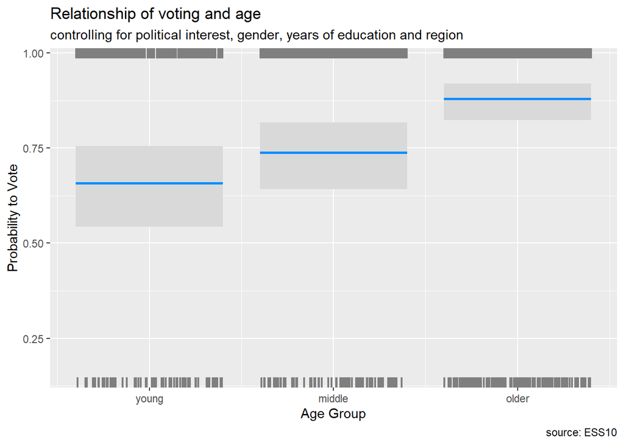

```r
visreg(logitmodel, "age_group",
       gg = TRUE,
       scale = "response") +
  labs(y = "Probability to Vote",
       x = "Age Group",
       title = "Relationship of voting and age",
       subtitle = "controlling for political interest, gender, years of education and region",
       caption = "source: ESS10")
```

The output shows the probability of the of the individual age groups to vote and the resulting plot can then be stored for future use or comparison.

```r
ggsave(filename = file.path("age_group.png"))
```

Out of curiosity and to verify the code is working and the results fit the prediction of the regression, the code has been replicated for all combinations of variables.

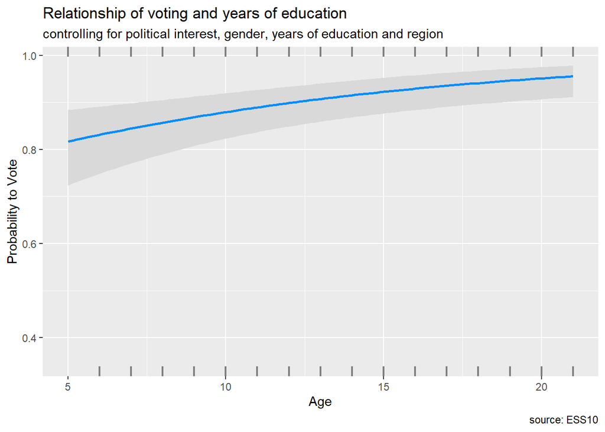

```r
#testing for "eduyrs"

visreg(logitmodel, "eduyrs",
       gg = TRUE,
       scale = "response") +
  labs(y = "Probability to Vote",
       x = "Age",
       title = "Relationship of voting and years of education",
       subtitle = "controlling for political interest, gender, years of education and region",
       caption = "source: ESS10")
```

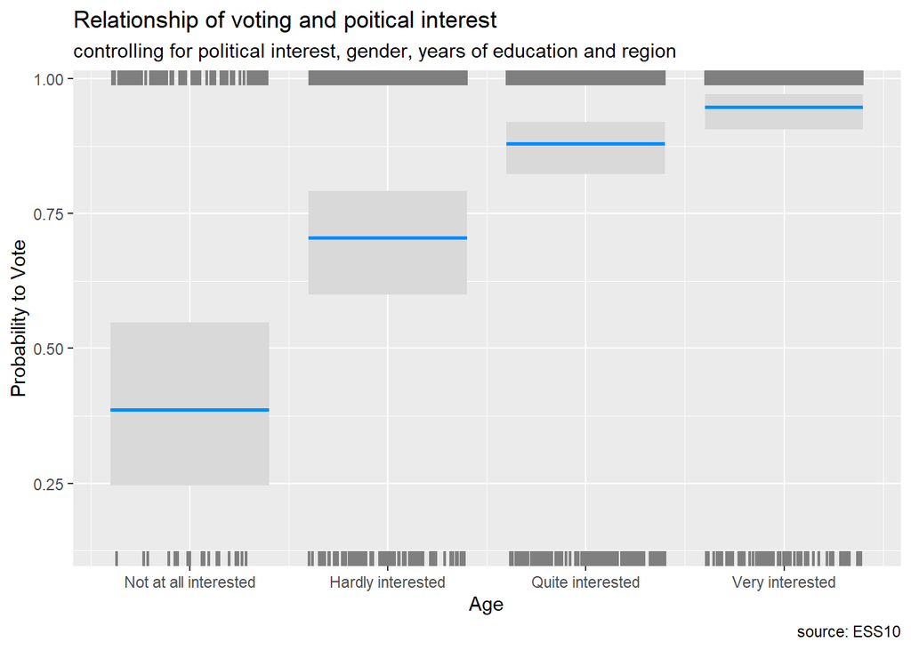

```r
#testing for "polintr"


visreg(logitmodel, "polintr",
       gg = TRUE,
       scale = "response") +
  labs(y = "Probability to Vote",
       x = "Age",
       title = "Relationship of voting and poitical interest",
       subtitle = "controlling for political interest, gender, years of education and region",
       caption = "source: ESS10")
```

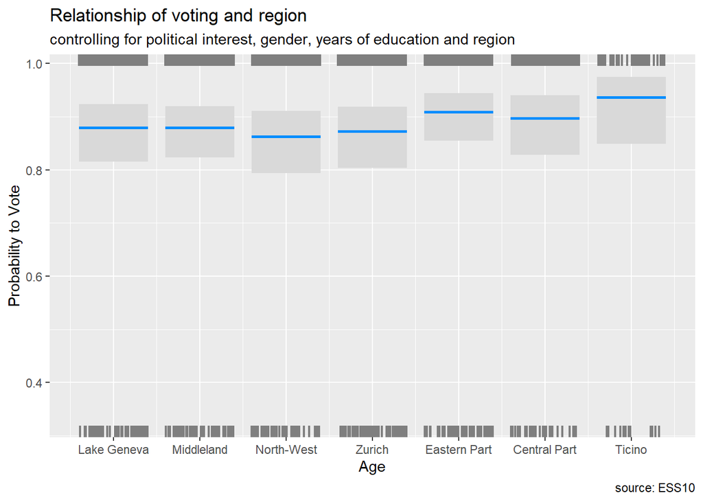

```r
#testing for "region"

visreg(logitmodel, "region",
       gg = TRUE,
       scale = "response") +
  labs(y = "Probability to Vote",
       x = "Age",
       title = "Relationship of voting and region",
       subtitle = "controlling for political interest, gender, years of education and region",
       caption = "source: ESS10")
```

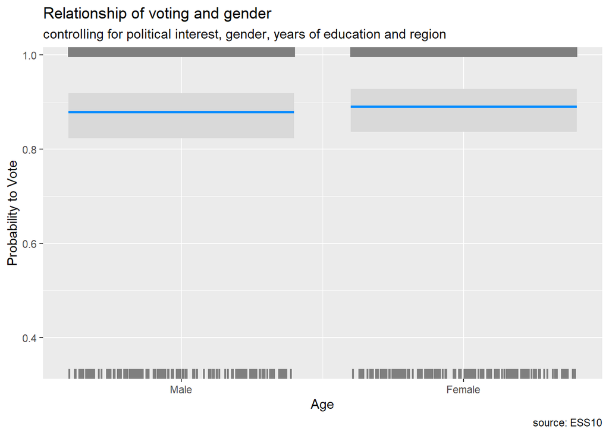

```r
#testing for "gndr"

visreg(logitmodel, "gndr",
       gg = TRUE,
       scale = "response") +
  labs(y = "Probability to Vote",
       x = "Age",
       title = "Relationship of voting and gender",
       subtitle = "controlling for political interest, gender, years of education and region",
       caption = "source: ESS10")
```

#### Conclusion

Our analysis reveals that older and middle-aged adults are more likely to vote than young adults. Thus, we have confirmed our hypothesis. Given that the analysis is based on observational data, the regression results must be interpreted descriptively, and not causally. Therefore, we conclude from our findings that voting is associated with increases in age, keeping all other factors fixed.

## Discussion

We set out to see, how age does affect voting participation. We hypothesized that older adults are more likely to vote than young adults.The regression and the visualization confirms this suspicion. However we concede that this is a limited analysis which could be easily expanded.Staying within the confines of Switzerland a panel analysis over several years could be considered. Or expanding the scope of the analysis between various countries of similar economic and social power and structure. On the other hand, data set we use contains still some variables that go unused, so these could either be removed for a cleaner data set or added for further analysis of the subject.